# BIA-658 Lab 4 Exercises

```r
# infomation allocation network:
# density: p-value <1e-04 is small, means -2.99318 is significant, and -2.99318 is negative, means the network is sparse.
# reciprocity: p-value 0.933 is higher than 0.05, means 0.08061 is not significant, so the network doesn't have significant levels of reciprocity
# transitivity: p-value <1e-04 is small, means 1.00158 is significant, so the network has significant levels of transitivity
```

Q3. Read EXeq.csv into R. Add the expertise vector as a node attribute to the information retrieval network. 1) Are people more likely to retrieve information from those with higher expertise? 2) Are people more likely to retrieve information from others if they have lower expertise? 3) Are people more likely to retrieve information from those with similar levels of expertise as they do? Conduct the tests and explain your results. - Create 3 models and add the 3 tests one by one - In the first model, include configurations you found significant from Q2 and add the main effect of expertise to test 1). - In the second model, if 1) is significant, keep it in the model and add the test of 2). Otherwise, drop the term testing 1) and add the new term to test 2). - Repeat the previous step in the third model when testing 3) by keeping all significant terms and dropping non-significant terms in previous tests. Note: The csv files have no headers, add col_names = F to your read_csv function

```r
ex <- read_csv(file="C:/Users/zhou/Desktop/BIA 658/Week 12 Lab 4/Lab4-Data/EXeq.csv", col_names=FALSE)
c_name <- c('Expertise')
names(ex) <- c_name
crieqs <- cbind(crieq, ex)
crieqmn%v%'Expertise' <- crieqs$Expertise

model1 <- ergm(crieqmn ~ edges + gwesp(0.5, fixed=T) + nodeicov("Expertise"), control=control.ergm(seed=1))
```

```
## Starting maximum pseudolikelihood estimation (MPLE):
```

```
## Evaluating the predictor and response matrix.
```

```
## Maximizing the pseudolikelihood.
```

```
## Finished MPLE.
```

```
## Starting Monte Carlo maximum likelihood estimation (MCMLE):
```

```
## Iteration 1 of at most 20:
```

```
## Optimizing with step length 1.
```

```
## The log-likelihood improved by 0.1583.
```

```
## Step length converged once. Increasing MCMC sample size.
```

```
## Iteration 2 of at most 20:
```

```
## Optimizing with step length 1.
```

```
## The log-likelihood improved by 0.004348.
```

```
## Step length converged twice. Stopping.
```

```
## Finished MCMLE.
```

```
## Evaluating log-likelihood at the estimate. Using 20 bridges: 1 2 3 4 5 6 7 8 9 10 11 12 13 14 15 16 17 18 19 20 .
## This model was fit using MCMC.  To examine model diagnostics and check
## for degeneracy, use the mcmc.diagnostics() function.
```

```r
summary(model1)
```

```
## Call:
## ergm(formula = crieqmn ~ edges + gwesp(0.5, fixed = T) + nodeicov("Expertise"),
##     control = control.ergm(seed = 1))
##
## Iterations:  2 out of 20
##
## Monte Carlo MLE Results:
##                    Estimate Std. Error MCMC % z value Pr(>|z|)
## edges               -6.3477     0.9425      0  -6.735   <1e-04 ***
## gwesp.fixed.0.5      0.6120     0.2386      0   2.564   0.0103 *
## nodeicov.Expertise   8.8298     2.0050      0   4.404   <1e-04 ***
## ---
## Signif. codes:  0 '***' 0.001 '**' 0.01 '*' 0.05 '.' 0.1 ' ' 1
##
##      Null Deviance: 377.1  on 272  degrees of freedom
##  Residual Deviance: 139.1  on 269  degrees of freedom
##
## AIC: 145.1    BIC: 155.9    (Smaller is better.)
```

```r
# p-value for nodeicov.Expertise parameter is <1e-04, which means it's significant, and 8.8298 is positive.
# so people are more likely to retrieve info from those with higher expertise.

model2 <- ergm(crieqmn ~ edges + gwesp(0.5, fixed=T) + nodeicov("Expertise") + nodeocov("Expertise"), control=control.ergm(seed=1))
```

```
## Starting maximum pseudolikelihood estimation (MPLE):
## Evaluating the predictor and response matrix.
## Maximizing the pseudolikelihood.
## Finished MPLE.
## Starting Monte Carlo maximum likelihood estimation (MCMLE):
## Iteration 1 of at most 20:
## Optimizing with step length 1.
## The log-likelihood improved by 0.0854.
## Step length converged once. Increasing MCMC sample size.
## Iteration 2 of at most 20:
## Optimizing with step length 1.
## The log-likelihood improved by 0.002648.
## Step length converged twice. Stopping.
## Finished MCMLE.
## Evaluating log-likelihood at the estimate. Using 20 bridges: 1 2 3 4 5 6 7 8 9 10 11 12 13 14 15 16 17 18 19 20 .
## This model was fit using MCMC.  To examine model diagnostics and check
## for degeneracy, use the mcmc.diagnostics() function.
```

```r
summary(model2)
```

```
## Call:
## ergm(formula = crieqmn ~ edges + gwesp(0.5, fixed = T) + nodeicov("Expertise") +
##     nodeocov("Expertise"), control = control.ergm(seed = 1))
##
## Iterations:  2 out of 20
##
## Monte Carlo MLE Results:
##                    Estimate Std. Error MCMC % z value Pr(>|z|)
## edges               -6.8196     1.1957      0  -5.703   <1e-04 ***
## gwesp.fixed.0.5      0.4588     0.3092      0   1.484    0.138
## nodeicov.Expertise   9.5677     2.3594      0   4.055   <1e-04 ***
## nodeocov.Expertise   1.1562     1.4042      0   0.823    0.410
## ---
## Signif. codes:  0 '***' 0.001 '**' 0.01 '*' 0.05 '.' 0.1 ' ' 1
##
##      Null Deviance: 377.1  on 272  degrees of freedom
##  Residual Deviance: 138.3  on 268  degrees of freedom
##
## AIC: 146.3    BIC: 160.7    (Smaller is better.)
```

```r
# p-value for nodeocov.Expertise is large as 0.410, so it's not significant
# so people are not likely to retrieve info from those with lower expertise.

model3 <- ergm(crieqmn ~ edges + gwesp(0.5, fixed=T) + nodeicov("Expertise") + absdiff("Expertise"), control=control.ergm(seed=1))
```

```
## Starting maximum pseudolikelihood estimation (MPLE):
## Evaluating the predictor and response matrix.
## Maximizing the pseudolikelihood.
## Finished MPLE.
## Starting Monte Carlo maximum likelihood estimation (MCMLE):
## Iteration 1 of at most 20:
## Optimizing with step length 1.
## The log-likelihood improved by 0.1116.
## Step length converged once. Increasing MCMC sample size.
## Iteration 2 of at most 20:
## Optimizing with step length 1.
## The log-likelihood improved by 0.006836.
## Step length converged twice. Stopping.
## Finished MCMLE.
## Evaluating log-likelihood at the estimate. Using 20 bridges: 1 2 3 4 5 6 7 8 9 10 11 12 13 14 15 16 17 18 19 20 .
## This model was fit using MCMC.  To examine model diagnostics and check
## for degeneracy, use the mcmc.diagnostics() function.
```

```r
summary(model3)
```

```
## Call:
## ergm(formula = crieqmn ~ edges + gwesp(0.5, fixed = T) + nodeicov("Expertise") +
##     absdiff("Expertise"), control = control.ergm(seed = 1))
##
## Iterations:  2 out of 20
##
## Monte Carlo MLE Results:
##                    Estimate Std. Error MCMC % z value Pr(>|z|)
## edges               -6.2324     1.0431      0  -5.975   <1e-04 ***
## gwesp.fixed.0.5      0.2654     0.3270      0   0.812   0.4170
## nodeicov.Expertise  11.2673     2.8294      0   3.982   <1e-04 ***
## absdiff.Expertise   -2.9303     1.7547      0  -1.670   0.0949 .
## ---
## Signif. codes:  0 '***' 0.001 '**' 0.01 '*' 0.05 '.' 0.1 ' ' 1
##
##      Null Deviance: 377.1  on 272  degrees of freedom
##  Residual Deviance: 135.7  on 268  degrees of freedom
##
## AIC: 143.7    BIC: 158.2    (Smaller is better.)
```

```r
# p-value for absdiff.Expertise is 0.0949 which is large, so no homophily effect.
# people are not likely to retrieve info from those with similar expertise.
```

Q4. Construct the final model to predict tie formation in the information retrieval network, keeping only significant configurations/effects you found through Q1-3. Test the goodness-of-fit of the model in terms of in & out degree distribution. Plot the goodness-of-fit results. Report and interpret your findings.

```r
model4 <- ergm(crieqmn ~ edges + gwesp(0.5, fixed=T) + nodeicov("Expertise"), control=control.ergm(seed=1))
```

```
## Starting maximum pseudolikelihood estimation (MPLE):
```

```
## Evaluating the predictor and response matrix.
```

```
## Maximizing the pseudolikelihood.
```

```
## Finished MPLE.
```

```
## Starting Monte Carlo maximum likelihood estimation (MCMLE):
```

```
## Iteration 1 of at most 20:
```

```
## Optimizing with step length 1.
```

```
## The log-likelihood improved by 0.1583.
```

```
## Step length converged once. Increasing MCMC sample size.
```

```
## Iteration 2 of at most 20:
```

```
## Optimizing with step length 1.
```

```
## The log-likelihood improved by 0.004348.
```

```
## Step length converged twice. Stopping.
```

```
## Finished MCMLE.
```

```
## Evaluating log-likelihood at the estimate. Using 20 bridges: 1 2 3 4 5 6 7 8 9 10 11 12 13 14 15 16 17 18 19 20 .
## This model was fit using MCMC.  To examine model diagnostics and check
## for degeneracy, use the mcmc.diagnostics() function.
```

```r
summary(model4)
```

```
## Call:
## ergm(formula = crieqmn ~ edges + gwesp(0.5, fixed = T) + nodeicov("Expertise"),
##     control = control.ergm(seed = 1))
##
## Iterations:  2 out of 20
##
## Monte Carlo MLE Results:
##                    Estimate Std. Error MCMC % z value Pr(>|z|)
## edges               -6.3477     0.9425      0  -6.735   <1e-04 ***
## gwesp.fixed.0.5      0.6120     0.2386      0   2.564   0.0103 *
## nodeicov.Expertise   8.8298     2.0050      0   4.404   <1e-04 ***
## ---
## Signif. codes:  0 '***' 0.001 '**' 0.01 '*' 0.05 '.' 0.1 ' ' 1
##
##      Null Deviance: 377.1  on 272  degrees of freedom
##  Residual Deviance: 139.1  on 269  degrees of freedom
##
## AIC: 145.1    BIC: 155.9    (Smaller is better.)
```

```r
model4.gof <- gof(model4 ~ idegree + odegree)
model4.gof
```

```
##
## Goodness-of-fit for in-degree
##
##    obs min mean max MC p-value
## 0    9   5 9.16  12       1.00
## 1    3   0 2.02   5       0.70
## 2    0   0 0.72   3       0.80
## 3    0   0 0.22   2       1.00
## 4    0   0 0.41   2       1.00
## 5    2   0 0.69   3       0.28
## 6    0   0 0.65   4       1.00
## 7    0   0 0.72   4       0.98
## 8    1   0 0.75   3       1.00
## 9    1   0 0.75   3       1.00
## 10   0   0 0.47   2       1.00
## 11   1   0 0.29   2       0.54
## 12   0   0 0.07   2       1.00
## 13   0   0 0.08   1       1.00
##
## Goodness-of-fit for out-degree
##
##   obs min mean max MC p-value
## 0   4   0 1.66   5       0.16
## 1   1   0 2.96   8       0.36
## 2   3   1 3.99   9       0.84
## 3   4   0 4.71  10       0.96
## 4   3   0 2.88   7       1.00
## 5   2   0 0.73   3       0.40
## 6   0   0 0.06   1       1.00
## 7   0   0 0.01   1       1.00
##
## Goodness-of-fit for model statistics
##
##                         obs       min     mean      max MC p-value
## edges              41.00000 22.000000 40.67000 53.00000       1.00
## gwesp.fixed.0.5    39.28801  6.393469 38.97542 62.32228       0.98
## nodeicov.Expertise 22.17647 12.117647 22.07706 28.82353       0.92
```

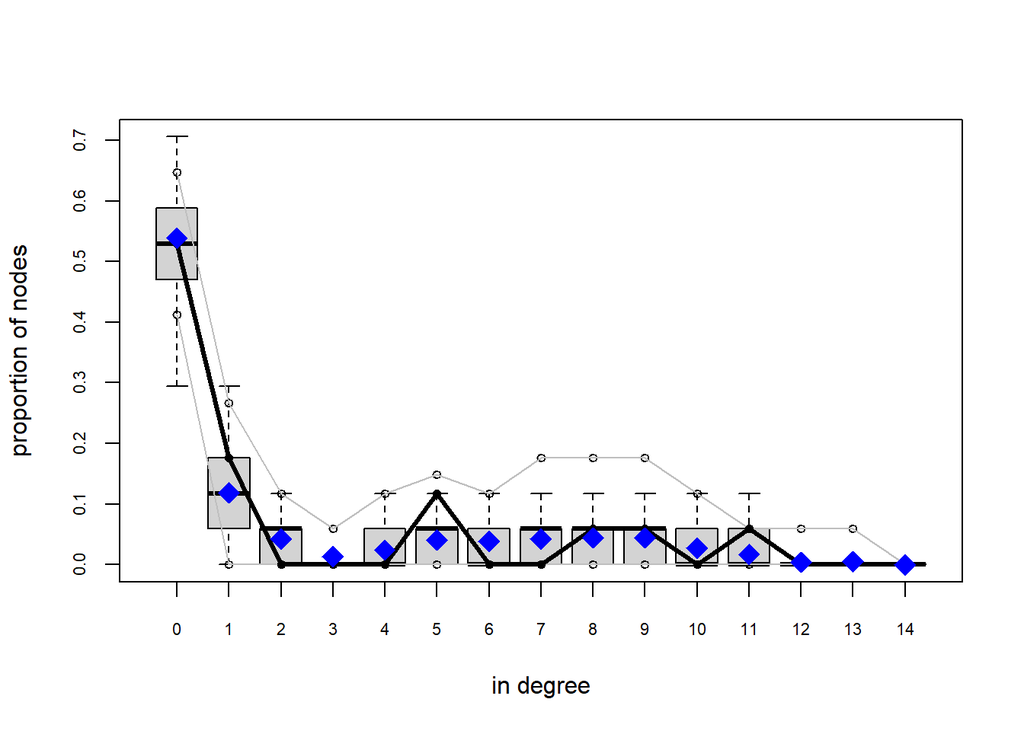

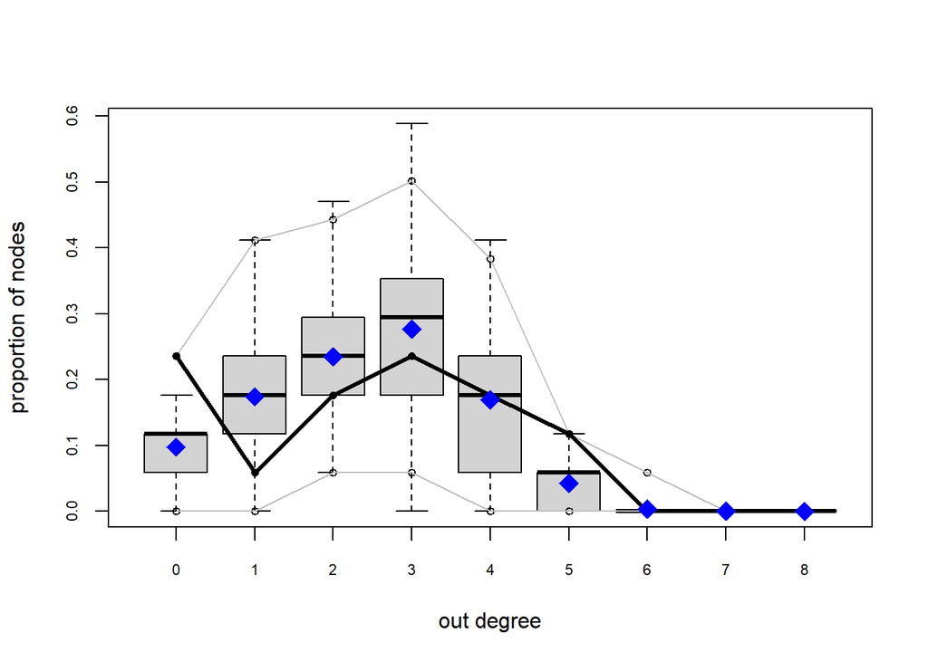

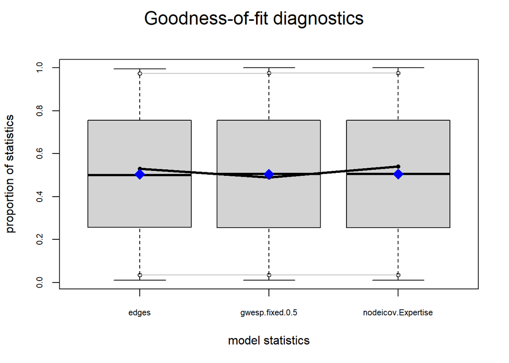

```r
plot(model4.gof)
```

```r
# Black solid line lies between two grey lines, which means the confidence interval of corresponding values in simulated networks. This is evidence that the model fits our actual network data pretty well.
# P values are high, indicating no significant difference between the observed data and data simulated by the model.
```